# Drawing beautiful maps programmatically with R, sf and ggplot2 - Part 3: Layouts

Mel Moreno and Mathieu Basille

# Drawing beautiful maps programmatically with R, `sf` and `ggplot2`

This tutorial is the third part in a series of three:

- General concepts illustrated with the world Map
- Adding additional layers: an example with points and polygons
- Positioning and layout for complex maps (this document)

After the presentation of basic map concepts, and the flexible approach in layers implemented in `ggplot2`, this part illustrates how to achieve complex layouts, for instance with map insets, or several maps combined. Depending on the visual information that needs to be displayed, maps and their corresponding data might need to be arranged to create easy to read graphical representations. This tutorial will provide different approaches to arranges maps in the plot, in order to make the information portrayed more aesthetically appealing, and most importantly, convey the information better.

## Getting started

Many R packages are available from [CRAN](https://cran.r-project.org/), the Comprehensive R Archive Network, which is the primary repository of R packages. The full list of packages necessary for this series of tutorials can be installed with:

```r
install.packages(c("cowplot", "googleway", "ggplot2", "ggrepel",
    "ggspatial", "libwgeom", "sf", "rnaturalearth", "rnaturalearthdata"))
```

We start by loading the basic packages necessary for all maps, i.e. `ggplot2` and `sf`. We also suggest to use the classic dark-on-light theme for `ggplot2` (`theme_bw`), which is more appropriate for maps:

```r
library("ggplot2")
theme_set(theme_bw())
library("sf")
```

The package `rnaturalearth` provides a map of countries of the entire world. Using `ne_counties` to pull the country data and,choose the scale. For `returnclass`, the setting can for be ‘sf’ and/or ‘sp’:

```r
library("rnaturalearth")
library("rnaturalearthdata")

world <- ne_countries(scale='medium',returnclass = 'sf')
class(world)
```

```
## [1] "sf"         "data.frame"
```

# General concepts

There are 2 solutions to combine sub-maps:

- Using “grobs”, i.e. graphic objects from `ggplot2`, which can be inserted in the plot region using plot coordinates;
- Using `ggdraw` from package `cowplot`, which allows to arrange new plots anywhere on the graphic device, including outer margins, based on relative position.

Here is a simple example illustrating the difference between the two, and their use. We first prepare a simple graph showing 11 points, with regular axes and grid (`g1`):

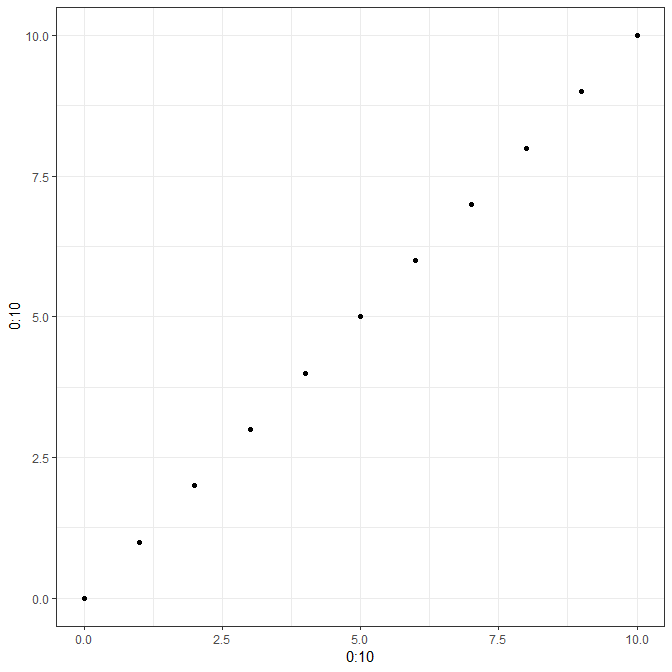

```r
(g1  <- qplot(0:10, 0:10))
```

Graphs from `ggplot2` can be saved, like any other R object. That allows to reuse and update the graph later on. For instance, we store in `g1_void`, a simplified version of this graph only the point data, but no decoration:

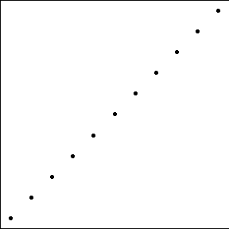

```r
(g1_void <- g1 + theme_void() + theme(panel.border = element_rect(colour = "black",
    fill = NA)))
```

The function `annotation_custom` allows to arrange graphs together in the form of grobs (generated with `ggplotGrob`). Here we first plot the full graph `g1`, and then add two instances of `g1_void` in the upper-left and bottom-right corners of the plot region (as defined by `xmin`, `xmax`, `ymin`, and `ymax`):

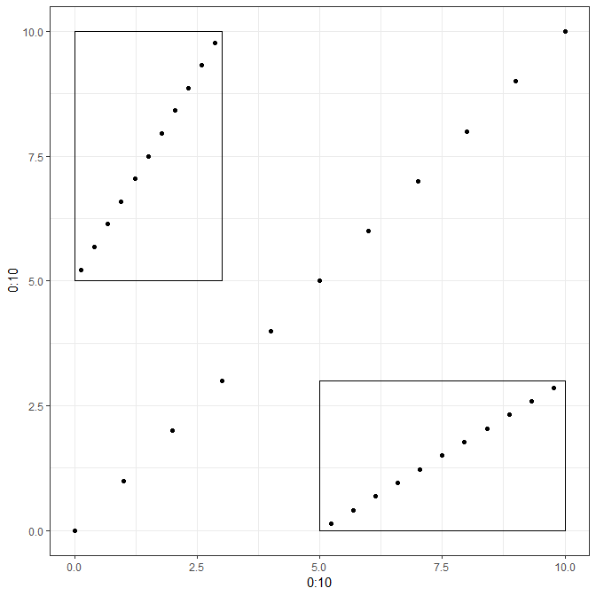

```r
g1 +
    annotation_custom(
        grob = ggplotGrob(g1_void),
        xmin = 0,
        xmax = 3,
        ymin = 5,
        ymax = 10
    ) +
    annotation_custom(
        grob = ggplotGrob(g1_void),
        xmin = 5,
        xmax = 10,
        ymin = 0,
        ymax = 3
    )
```

An alternative using the function `ggdraw` from the package `cowplot` allows to use relative positioning in the entire plot device. In this case, we build the graph on top of `g1`, but the initial call to `ggdraw` could actually be left empty to arrange subplots on an empty plot. Width and height of the subplots are relative from 0 to 1, as well x and y coordinates ([0,0] being the lower-left corner, [1,1] being the upper-right corner).

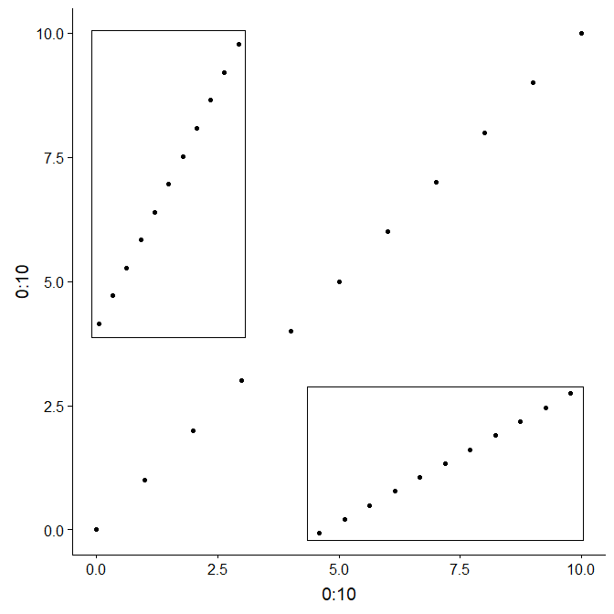

```r
ggdraw(g1) +
    draw_plot(g1_void, width = 0.25, height = 0.5, x = 0.15, y = 0.45) +
    draw_plot(g1_void, width = 0.45, height = 0.25, x = 0.50, y = 0.12)
```

# Several maps side by side or on a grid

In this section, we present a way to arrange several maps side by side on a grid. While this could be achieved manually after exporting each individual map, this allows to 1) have reproducible code to this end; 2) full control on how individual maps are positioned.

This exmaple is using two maps side by side, including the legend of the first one. It illustrates how to use a custom grid, which can be made a lot more complex with different elements.

We now prepare the subplots, starting by the world map with a rectangle around the Gulf of Mexico (see Section 1 and 2 for the details of how to prepare this map):

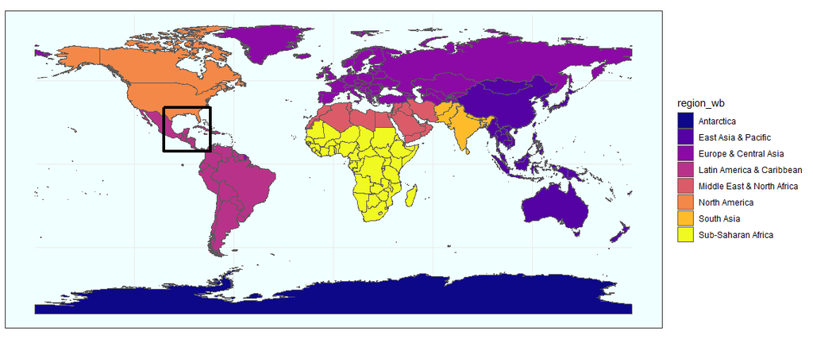

```r
(gworld <- ggplot(data = world) +
     geom_sf(aes(fill = region_wb)) +
     geom_rect(xmin = -102.15, xmax = -74.12, ymin = 7.65, ymax = 33.97,
         fill = NA, colour = "black", size = 1.5) +
     scale_fill_viridis_d(option = "plasma") +
     theme(panel.background = element_rect(fill = "azure"),
         panel.border = element_rect(fill = NA)))
```

The second map is very similar, but centered on the Gulf of Mexico (using `coord_sf`):

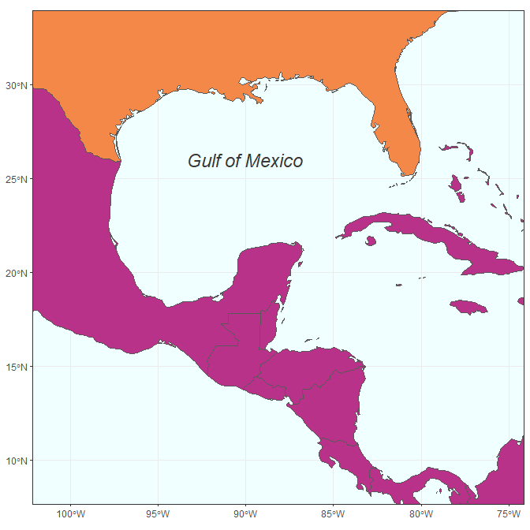

```r
(ggulf <- ggplot(data = world) +
     geom_sf(aes(fill = region_wb)) +
     annotate(geom = "text", x = -90, y = 26, label = "Gulf of Mexico",
         fontface = "italic", color = "grey22", size = 6) +
     coord_sf(xlim = c(-102.15, -74.12), ylim = c(7.65, 33.97), expand = FALSE) +
     scale_fill_viridis_d(option = "plasma") +
     theme(legend.position = "none", axis.title.x = element_blank(),
         axis.title.y = element_blank(), panel.background = element_rect(fill = "azure"),
         panel.border = element_rect(fill = NA)))
```

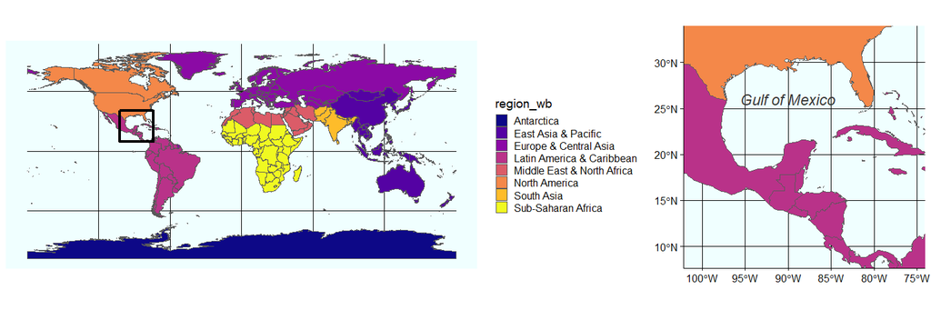

```r
ggplot() +
    coord_equal(xlim = c(0, 3.3), ylim = c(0, 1), expand = FALSE) +
    annotation_custom(ggplotGrob(gworld), xmin = 0, xmax = 2.3, ymin = 0,
        ymax = 1) +
    annotation_custom(ggplotGrob(ggulf), xmin = 2.3, xmax = 3.3, ymin = 0,
        ymax = 1) +
    theme_void()
```

The second approach using the function `plot_grid` from `cowplot` to arrange `ggplot` figures, is quite versatile. Any `ggplot` figure can be arranged just like the figure above. Several arguments adjust map placement, such as `nrow` and `ncol` which define the number of row and columns, respectively, and `rel_widths` which establishes the relative width of each map. In our case, we want both maps on a single row, the first map `gworld` to have a relative width of `2.3`, and the map `ggulf` a relative width of `1`.

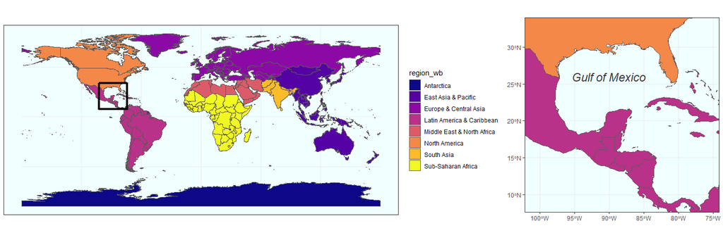

```r
library("cowplot")
theme_set(theme_bw())

plot_grid(gworld, ggulf, nrow = 1, rel_widths = c(2.3, 1))
```

The argument `align` allows to align subplots horizontally (`align = "h"`), vertically (`align = "v"`), or both (`align = "hv"`), so that the axes and plot region match each other. Note also the existence of `get_legend` (`cowplot`), which extract the legend of a plot, which can then be used as any object (for instance, to place it precisely somewhere on the map).  
Both maps created above (using `ggplot` and `annotation_custom`, or using `cowplot` and `plot_grid`) can be saved as usual using `ggsave` (to be used after plotting the desired map):

```r
ggsave("world_grid.pdf", width = 15, height =  5)
```

# Map insets

To inset maps directly on a background map, both solutions presented earlier are viable (and one might prefer one or the other depending on relative or absolute coordinates). We will illustrate this using a map of the 50 states of the United States, including Alaska and Hawaii (note: both Alaska and Hawaii will not be to scale).

We start by preparing the continental states first, using the reference US National Atlas Equal Area projection. The main trick is to find the right coordinates, in the projection used, and this may cause some fine tuning at each step. Here, we enlarge the extent of the plot region on purpose to give some room for the insets:

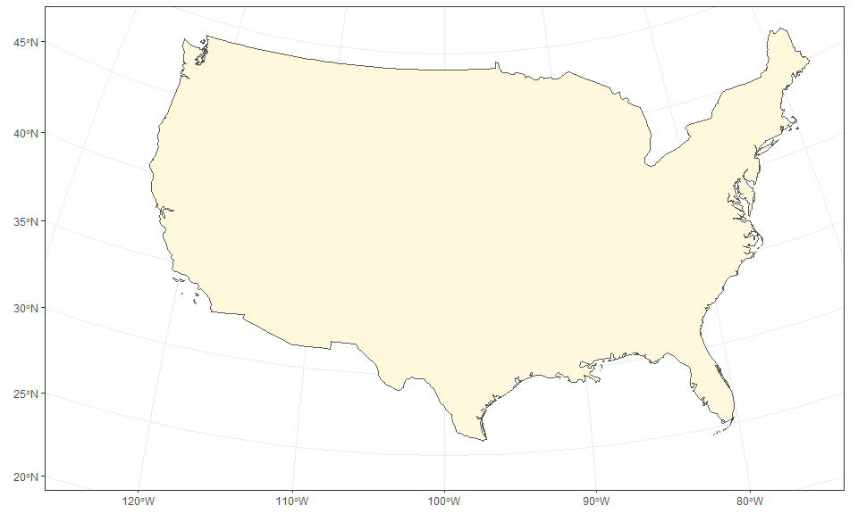

```r
usa <- subset(world, admin == "United States of America")
## US National Atlas Equal Area (2163)
## http://spatialreference.org/ref/epsg/us-national-atlas-equal-area/
(mainland <- ggplot(data = usa) +
     geom_sf(fill = "cornsilk") +
     coord_sf(crs = st_crs(2163), xlim = c(-2500000, 2500000), ylim = c(-2300000,
         730000)))
```

The Alaska map is plotted using the reference Alaska Albers projection (note that graticules and coordinates are removed with `datum = NA`):

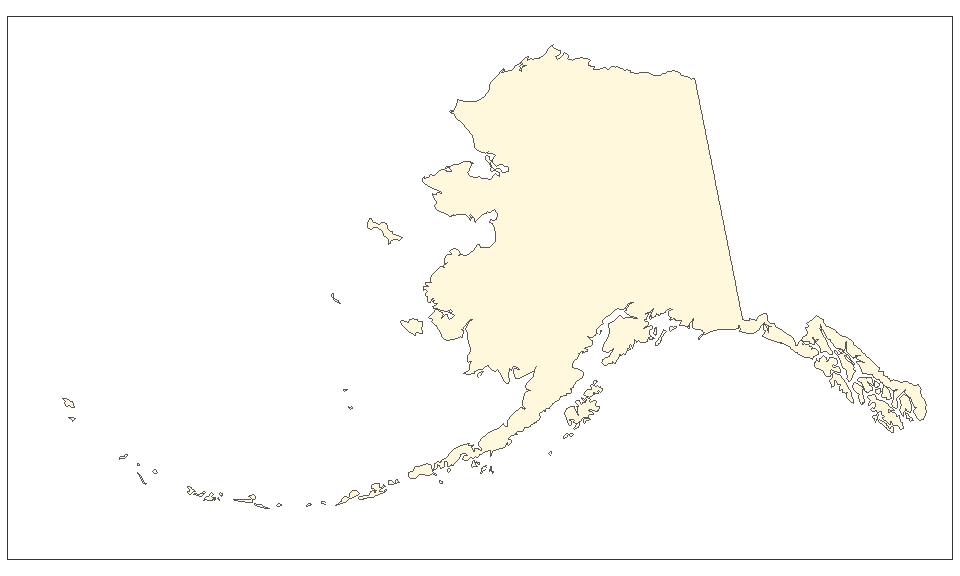

```r
## Alaska: NAD83(NSRS2007) / Alaska Albers (3467)
## http://www.spatialreference.org/ref/epsg/3467/
(alaska <- ggplot(data = usa) +
     geom_sf(fill = "cornsilk") +
     coord_sf(crs = st_crs(3467), xlim = c(-2400000, 1600000), ylim = c(200000,
         2500000), expand = FALSE, datum = NA))
```

And now the map of Hawaii, plotted using the reference Old Hawaiian projection:

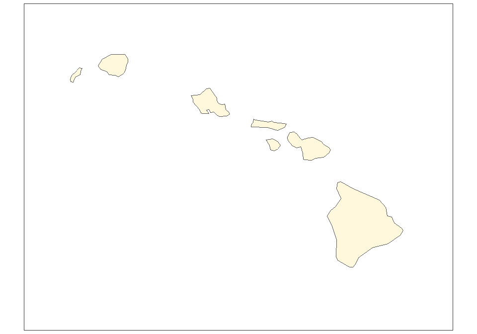

```r
## Hawaii: Old Hawaiian (4135)
## http://www.spatialreference.org/ref/epsg/4135/
(hawaii  <- ggplot(data = usa) +
     geom_sf(fill = "cornsilk") +
     coord_sf(crs = st_crs(4135), xlim = c(-161, -154), ylim = c(18,
         23), expand = FALSE, datum = NA))
```

The final map can be created using `ggplot2` only, with the help of the function `annotation_custom`. In this case, we use arbitrary ratios based on the size of the subsets above (note the difference based on maximum minus minimum x/y coordinates):

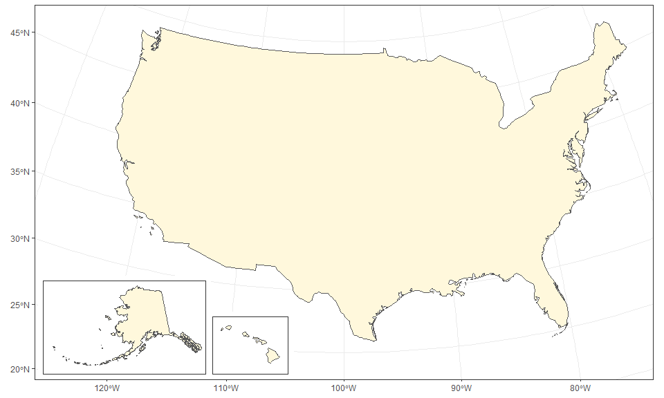

```r
mainland +
    annotation_custom(
        grob = ggplotGrob(alaska),
        xmin = -2750000,
        xmax = -2750000 + (1600000 - (-2400000))/2.5,
        ymin = -2450000,
        ymax = -2450000 + (2500000 - 200000)/2.5
    ) +
    annotation_custom(
        grob = ggplotGrob(hawaii),
        xmin = -1250000,
        xmax = -1250000 + (-154 - (-161))*120000,
        ymin = -2450000,
        ymax = -2450000 + (23 - 18)*120000
    )
```

The same can be achieved with the same logic using `cowplot` and the function `draw_plot`, in which case it is easier to define the ratios of Alaska and Hawaii first:

```r
(ratioAlaska <- (2500000 - 200000) / (1600000 - (-2400000)))
```

```
## [1] 0.575
```

```r
(ratioHawaii  <- (23 - 18) / (-154 - (-161)))
```

```
## [1] 0.7142857
```

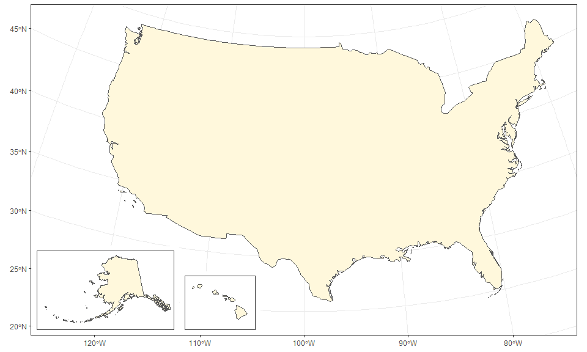

```r
ggdraw(mainland) +
    draw_plot(alaska, width = 0.26, height = 0.26 * 10/6 * ratioAlaska,
        x = 0.05, y = 0.05) +
    draw_plot(hawaii, width = 0.15, height = 0.15 * 10/6 * ratioHawaii,
        x = 0.3, y = 0.05)
```

Again, both plots can be saved using `ggsave`:

```r
ggsave("us-alaska-hawaii.pdf", width = 10, height = 6)
```

The `print` command can also be used place multiple maps in one plotting area.

To specify where each plot is displayed with the `print` function, the argument `viewport` needs to specify the maximum width and height of each map, and the minimum x and y coordinates of where the maps are located in the plotting area. The argument `just` will make a position on how the secondary maps will be displayed. All maps are defaulted the same size, until the sizes are adjusted with `width` and `height`.

```r
vp <- viewport(width = 0.37, height = 0.10, x = 0.20, y =0.25, just = c("bottom"))
vp1<- viewport(width = 0.37, height = 0.10, x = 0.35, y =0.25, just = c("bottom"))
```

The`print` function uses the previous specifications that were listed in each plots’ respective `viewport`, with `vp=`.

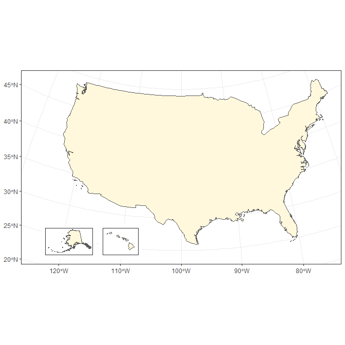

```r
print(mainland)
print(alaska, vp=vp)
print(hawaii, vp=vp1)
```

# Several maps connected with arrows

To bring about a more lively map arrangement, arrows can be used to direct the viewer’s eyes to specific areas in the plot. The next example will create a map with zoomed in areas, connected by arrows.

```r
sites <- st_as_sf(data.frame(longitude = c(-80.15, -80.1), latitude = c(26.5,
    26.8)), coords = c("longitude", "latitude"), crs = 4326,
    agr = "constant")
```

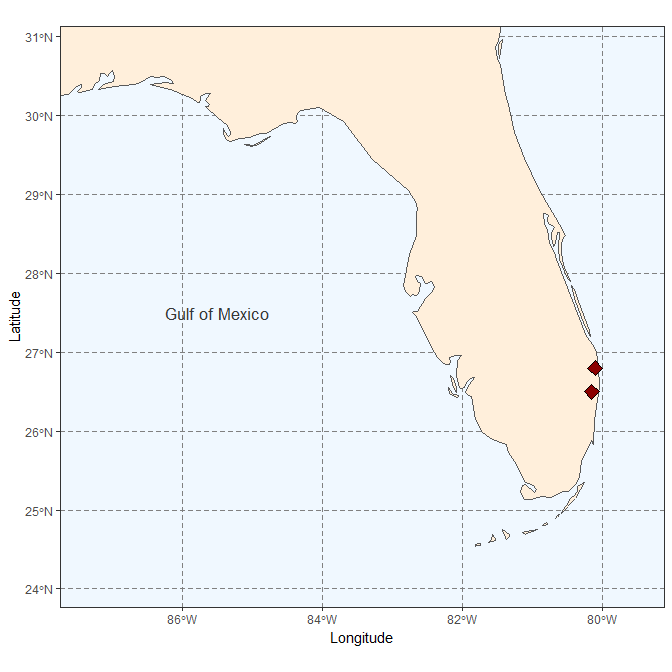

```r
(florida <- ggplot(data = world) +
     geom_sf(fill = "antiquewhite1") +
     geom_sf(data = sites, size = 4, shape = 23, fill = "darkred") +
     annotate(geom = "text", x = -85.5, y = 27.5, label = "Gulf of Mexico",
         color = "grey22", size = 4.5) +
     coord_sf(xlim = c(-87.35, -79.5), ylim = c(24.1, 30.8)) +
     xlab("Longitude")+ ylab("Latitude")+
     theme(panel.grid.major = element_line(colour = gray(0.5), linetype = "dashed",
         size = 0.5), panel.background = element_rect(fill = "aliceblue"),
         panel.border = element_rect(fill = NA)))
```

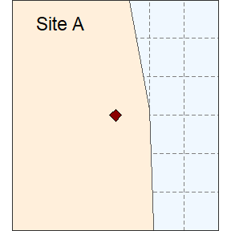

```r
(siteA <- ggplot(data = world) +
     geom_sf(fill = "antiquewhite1") +
     geom_sf(data = sites, size = 4, shape = 23, fill = "darkred") +
     coord_sf(xlim = c(-80.25, -79.95), ylim = c(26.65, 26.95), expand = FALSE) +
     annotate("text", x = -80.18, y = 26.92, label= "Site A", size = 6) +
     theme_void() +
     theme(panel.grid.major = element_line(colour = gray(0.5), linetype = "dashed",
         size = 0.5), panel.background = element_rect(fill = "aliceblue"),
         panel.border = element_rect(fill = NA)))
```

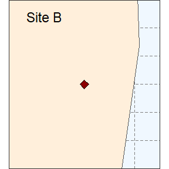

```r
(siteB <- ggplot(data = world) +
     geom_sf(fill = "antiquewhite1") +
     geom_sf(data = sites, size = 4, shape = 23, fill = "darkred") +
     coord_sf(xlim = c(-80.3, -80), ylim = c(26.35, 26.65), expand = FALSE) +
     annotate("text", x = -80.23, y = 26.62, label= "Site B", size = 6) +
     theme_void() +
     theme(panel.grid.major = element_line(colour = gray(0.5), linetype = "dashed",
         size = 0.5), panel.background = element_rect(fill = "aliceblue"),
         panel.border = element_rect(fill = NA)))
```

As we want to connect the two subplots to main map using arrows, the coordinates of the two arrows will need to be specified before plotting. We prepare a `data.frame` storing start and end coordinates (`x1` and `x2` on the x-axis, `y1` and `y2` on the y-axis):

```r
arrowA <- data.frame(x1 = 18.5, x2 = 23, y1 = 9.5, y2 = 14.5)
arrowB <- data.frame(x1 = 18.5, x2 = 23, y1 = 8.5, y2 = 6.5)
```

Using `ggplot` only, we simply follow the same approach as before to place several maps side by side, and then add arrows using the function `geom_segment` and the argument `arrow = arrow()`:

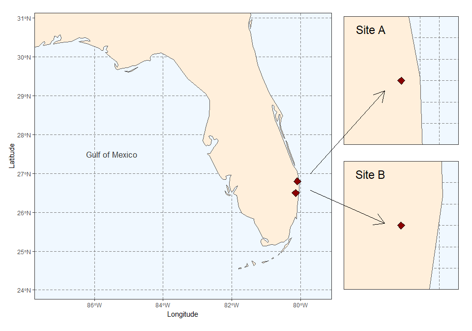

```r
ggplot() +
    coord_equal(xlim = c(0, 28), ylim = c(0, 20), expand = FALSE) +
    annotation_custom(ggplotGrob(florida), xmin = 0, xmax = 20, ymin = 0,
        ymax = 20) +
    annotation_custom(ggplotGrob(siteA), xmin = 20, xmax = 28, ymin = 11.25,
        ymax = 19) +
    annotation_custom(ggplotGrob(siteB), xmin = 20, xmax = 28, ymin = 2.5,
        ymax = 10.25) +
    geom_segment(aes(x = x1, y = y1, xend = x2, yend = y2), data = arrowA,
        arrow = arrow(), lineend = "round") +
    geom_segment(aes(x = x1, y = y1, xend = x2, yend = y2), data = arrowB,
        arrow = arrow(), lineend = "round") +
    theme_void()
```

The package `cowplot` (with `draw_plot`) can also be used for a similar result, with maybe a somewhat easier syntax:

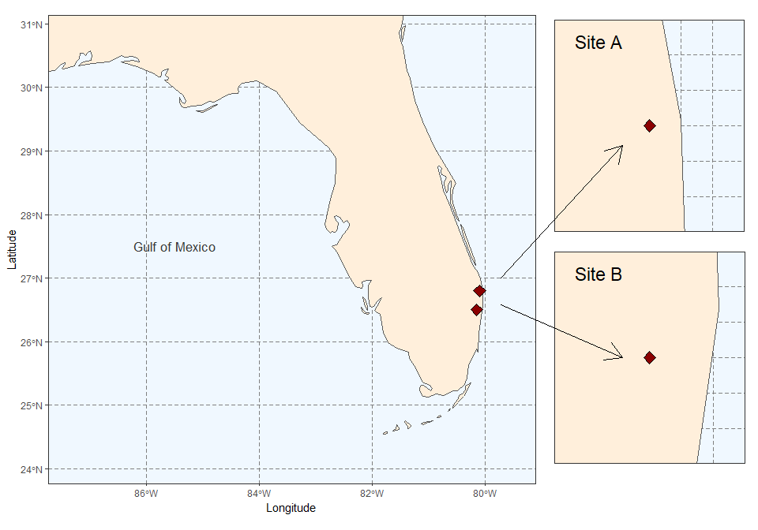

```r
ggdraw(xlim = c(0, 28), ylim = c(0, 20)) +
    draw_plot(florida, x = 0, y = 0, width = 20, height = 20) +
    draw_plot(siteA, x = 20, y = 11.25, width = 8, height = 8) +
    draw_plot(siteB, x = 20, y = 2.5, width = 8, height = 8) +
    geom_segment(aes(x = x1, y = y1, xend = x2, yend = y2), data = arrowA,
        arrow = arrow(), lineend = "round") +
    geom_segment(aes(x = x1, y = y1, xend = x2, yend = y2), data = arrowB,
        arrow = arrow(), lineend = "round")
```

Again, both plot can be saved using `ggsave`:

```r
ggsave("florida-sites.pdf", width = 10, height = 7)
```

# Faceting

## `ggplot2` for faceting

In the example below. The map data is faceted with `ggplot` and filled with the income group of each region. Regardless of the data, `ggplot` faceting has some limitations and much less flexible with the type of data it can plot. For `ggplot` to plot using `facet_wrap`, all data must exist in a single data frame, and be arranged in a long format.

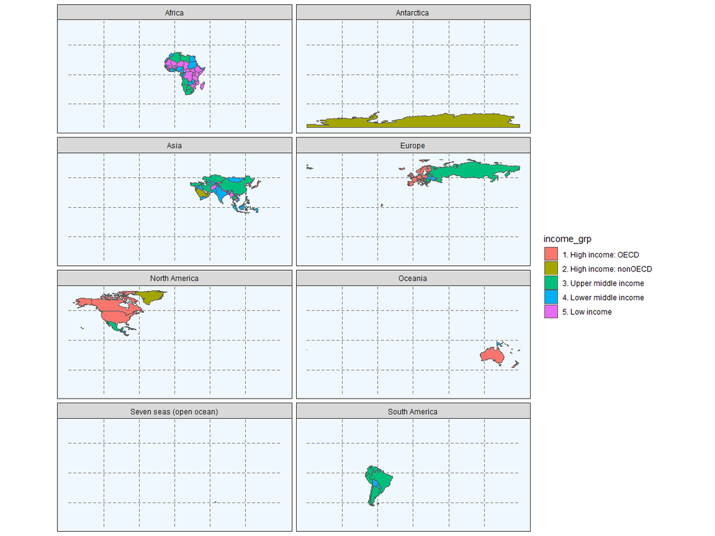

```r
library("rnaturalearth")

countries<-ne_countries(scale = 110, type = c("countries", "map_units", "sovereignty",
"tiny_countries"),returnclass = "sf")


ggplot(data = countries, aes(fill= income_grp)) +
     geom_sf() +
     theme(panel.grid.major = element_line(colour = gray(0.5), linetype = "dashed",
         size = 0.5), panel.background = element_rect(fill = "aliceblue"),
         panel.border = element_rect(fill = NA),
         axis.text.x = element_text(angle = 90)) +
  facet_wrap(~continent, ncol=2)
```